# Detecção de Outliers

Prof. Cesar Henrique Comin

## Detecção de outliers

- Um **outlier** é uma observação que se afasta do padrão do restante dos dados.
- Média, desvio-padrão, variância e correlação são somas sobre todos os pontos. Um valor muito grande domina a soma sozinho.
- Mínimos quadrados penalizam o erro ao quadrado, então o ajuste se desloca em direção ao ponto distante.

## Influência de um ponto na regressão linear

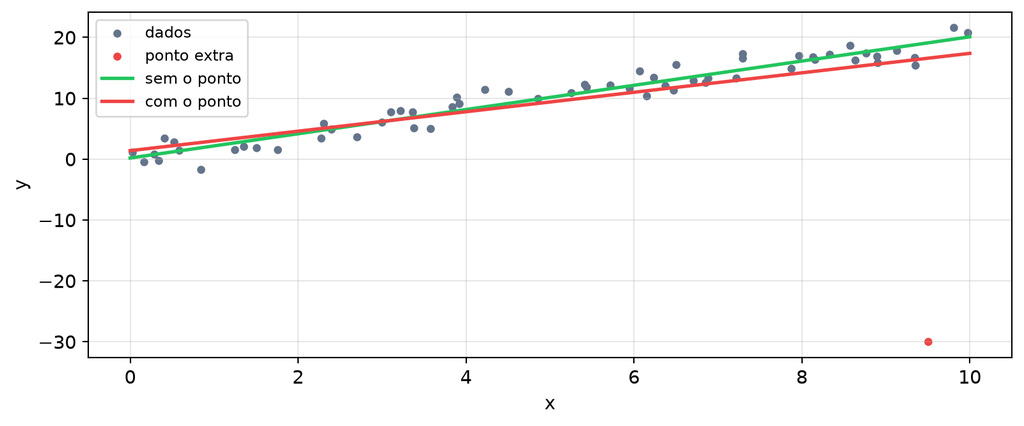

```
Inclinação sem outlier: 1.99
Inclinação com outlier: 1.60
```

## Outlier não é uma propriedade absoluta

- Não existe um teste que decida se um valor é outlier. O que existe são **regras de corte** que dependem de uma referência escolhida por quem analisa.
- A mesma linha de uma tabela pode ser descartável em uma análise e o resultado mais importante em outra.
- Por isso a pergunta útil não é “este ponto é um outlier?”, e sim **“de onde ele veio e o que ele faz com o que eu quero calcular?”**.

# Tipos de outliers

## Três origens

1. **Erro nos dados:** o valor registrado não corresponde ao que aconteceu.
2. **Extremo legítimo:** o valor está certo e a distribuição realmente tem cauda longa.
3. **Novidade:** o processo mudou, ou apareceu um caso de um tipo que ainda não existia.
- As três produzem pontos distantes. A ação correta é diferente em cada caso.

## Erro nos dados

- Erro de medição de um sensor.
- Sentinela numérica no lugar de ausente: `-999`, `9999`, `-1`, ou data em 01/01/1970.
- Unidade trocada em parte dos registros: gramas onde se esperava quilos, Fahrenheit onde se esperava Celsius.
- Vírgula decimal perdida na exportação, multiplicando o valor por cem.

## Extremo legítimo

- Em muitos domínios a cauda longa é o comportamento normal do fenômeno.
- Renda, valor de transação, tempo de resposta de um serviço, tamanho de arquivo, número de seguidores.
- Nesses casos o valor extremo carrega a informação que interessa. Descartar apaga parte do fenômeno e enviesa a estimativa feita depois.

## Novidade

- O processo mudou: um produto novo, uma promoção, um cliente de outro porte, um regime de operação diferente.
- Em fraude, falha de equipamento e intrusão, o ponto anômalo é **o resultado desejado**, não o resíduo a ser limpo.
- A mesma técnica serve para as duas coisas. O que muda é o destino do que foi encontrado.

## Impossível ou apenas improvável

- **Impossível:** idade $-5$, percentual $130$, data de alta anterior à internação. Isso é violação de regra de domínio e foi abordado em aulas anteriores.
- **Improvável:** idade $119$, compra de R$ 80 mil, tempo de resposta de 40 dias. Pode ser verdade.
- A regra de domínio vem primeiro. Ela é mais barata, mais confiável e não depende de nenhuma suposição estatística.

## Pontual, contextual e coletivo

- Uma segunda taxonomia, por **estrutura** em vez de origem.
- **Pontual:** um valor isolado longe de todos os outros.
- **Contextual:** o valor é comum na coluna, mas não naquele contexto. Trinta graus é normal em janeiro e anômalo em julho.
- **Coletivo:** cada valor é normal, mas a **sequência** não é. Um trecho constante indica sensor travado, mesmo que o valor repetido seja plausível.

## Pontual, contextual e coletivo

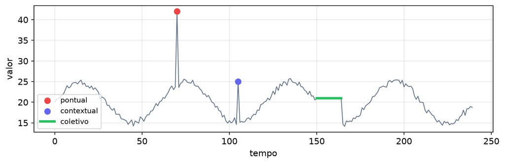

- Os métodos que veremos encontram bem o caso **pontual**. Os outros dois exigem construir a referência local antes.

# Detecção univariada

## Os dados de exemplo

- Um reator possui temperaturas típicas na faixa de $18^\circ C$ a $22^\circ C$.
- Vamos simular a temperatura medida no reator, com algumas falhas de medida e alguns picos de temperatura reais:

```python
rng = np.random.default_rng(1)

readings = rng.normal(20, 2, 500)        # temperatura de um reator, em graus Celsius
sensor_failure = np.arange(0, 500, 25)   # 20 posições onde o sensor falhou
real_spikes = np.array([137, 288, 411])  # 3 superaquecimentos reais

readings[sensor_failure] = -999.0        # sentinela gravada pelo equipamento
readings[real_spikes] = 30.0             # o que realmente interessa detectar
```

## Olhar antes de automatizar

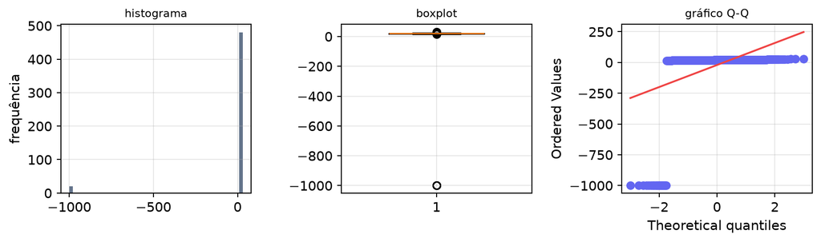

- Histograma, boxplot e o gráfico Q-Q são a primeira ferramenta para verificação dos dados. Veremos em mais detalhes em aulas futuras.

## Limiar de z-score

- O **z-score** mede a distância de um ponto até a média em unidades de desvio-padrão:

$$z = \frac{x - \mu}{\sigma}$$

- Podemos marcar como outlier todo ponto com $|z| > t$.
- É o método mais conhecido e o mais frágil.

## z-score em código

```python
mean = readings.mean()
std = readings.std()
z = (readings - mean) / std

print(f"média: {mean:.1f} | desvio-padrão: {std:.1f}")
print(f"z das sentinelas: {z[sensor_failure][:3].round(2)}")
print(f"z dos superaquecimentos: {z[real_spikes].round(2)}")
print(f"total marcado com |z| > 3: {(np.abs(z) > 3).sum()}")
```

```
média: -20.8 | desvio-padrão: 199.7
z das sentinelas: [-4.9 -4.9 -4.9]
z dos superaquecimentos: [0.25 0.25 0.25]
total marcado com |z| > 3: 20
```

## Mascaramento

- Os $20$ valores de $-999$ entraram no cálculo de $\mu$ e de $\sigma$.
- A média desceu para perto de $-20$ e o desvio-padrão subiu de $2$ para quase $200$.
- Nessa escala, uma leitura de $30$ graus fica a $0{,}25$ desvio da média. Ela é **mascarada** pelos próprios outliers.
- Resultado: o método encontra os sentinelas mas não encontra os superaquecimentos.

## z robusto com MAD

- **MAD** é o desvio absoluto mediano:

$$\text{MAD} = \text{mediana}\big(|x_i - \text{mediana}(x)|\big)$$

$$z_{\text{rob}} = \frac{0{,}6745\,(x - \text{mediana}(x))}{\text{MAD}}$$

- A constante $0{,}6745$ deixa o resultado comparável ao z-score usual, porque em uma distribuição normal o MAD vale $0{,}6745\,\sigma$.
- Limiar usual: $|z_{\text{rob}}| > 3{,}5$.

## z robusto em código

```python
median = np.median(readings)
mad = np.median(np.abs(readings - median))
z_robust = 0.6745*(readings - median) / mad

print(f"mediana: {median:.1f} | MAD: {mad:.2f}")
print(f"z robusto das sentinelas: {z_robust[sensor_failure][:3].round(1)}")
print(f"z robusto dos superaquecimentos: {z_robust[real_spikes].round(1)}")
print(f"total marcado com |z| > 3.5: {(np.abs(z_robust) > 3.5).sum()}")
```

```
mediana: 19.9 | MAD: 1.26
z robusto das sentinelas: [-546.2 -546.2 -546.2]
z robusto dos superaquecimentos: [5.4 5.4 5.4]
total marcado com |z| > 3.5: 23
```

- A mediana e o MAD ignoram os $4\%$ de sentinelas, então os superaquecimentos são detectados.

## Quando o MAD falha

- Quando mais da metade dos valores é igual a zero, o MAD é zero e a divisão dá erro.
- Acontece em contagens, colunas zero-infladas e variáveis muito discretas.
- Alternativa nesses casos: usar quantis diretamente, como no IQR.

## Regra do IQR

$$\begin{align}
& \text{IQR} = Q_3 - Q_1 \\
& \text{limites} = \big[\,Q_1 - 1{,}5\,\text{IQR},\; Q_3 + 1{,}5\,\text{IQR}\,\big]
\end{align}$$

- Em dados normais o fator $1{,}5$ marca cerca de $0{,}7\%$ dos pontos. O fator $3$ é usado quando se quer marcar apenas o caso extremo.

## Corte por percentil

```python
lower, upper = np.percentile(x, [0.5, 99.5])
```

- Não supõe distribuição nenhuma e a fração marcada é conhecida de antemão.
- É a base da **winsorização**, que veremos adiante.
- Desvantagem: o método sempre marca essa fração, mesmo em dados perfeitamente limpos, e nunca marca mais do que ela, mesmo que existam muito mais defeitos.

## Raridade não é erro

- Em um milhão de linhas perfeitamente normais, cerca de $3000$ ficam além de três desvios.
- Quanto maior a base, mais pontos extremos aparecem, sem que nada esteja errado.
- Métodos de corte identificam **valores raros**, e não **valores incorretos**.
- Por isso a inspeção de alguns casos marcados é parte do procedimento.

## Outliers em variáveis categóricas

- O equivalente categórico do outlier é a **categoria rara**.
- Categorias com pouquíssimas ocorrências em geral não sustentam nenhuma estimativa e costumam ser agrupadas em `"outros"`, que é o que o `min_frequency` do `OneHotEncoder` faz.
- Elas costumam ser erro de digitação, incluindo variações de ortografia e espaços em branco.

# Detecção multivariada

## Por que a univariada não basta

- Vamos simular um conjunto de dados com duas colunas: altura e peso de $300$ pessoas.
- O peso de algumas pessoas foi medido em uma balança descalibrada, que marcava $20$ kg a menos:

```python
rng_m = np.random.default_rng(4)
n = 300

# altura em cm
height = rng_m.normal(170, 8, n)
# peso em kg como uma função da altura + ruído
weight = 0.9*(height - 170) + 70 + rng_m.normal(0, 4, n)

# 60 pesos foram coletadas em uma balança descalibrada, que marcava 20 kg a menos
broken = np.arange(60)
weight[broken] -= 20

measures = np.column_stack([height, weight])
```

## Por que a univariada não basta

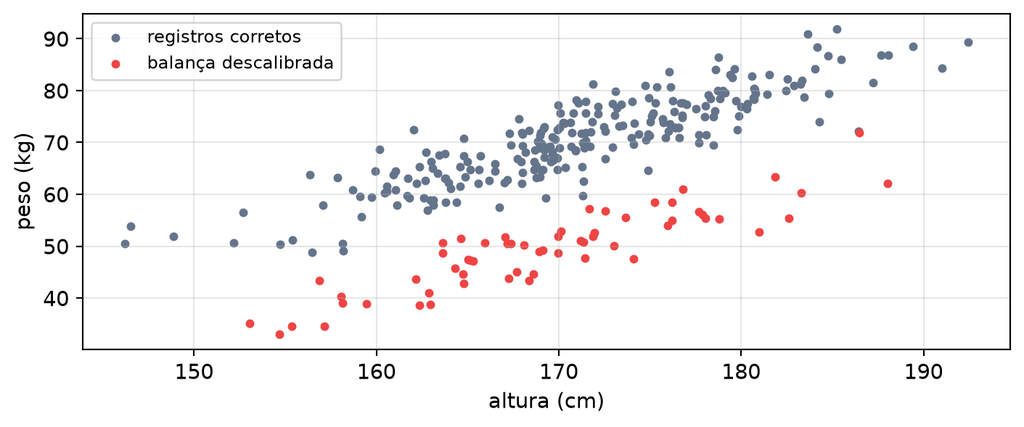

- Cada peso registrado continua sendo um peso comum, e cada altura continua sendo uma altura comum. O que denuncia o problema é a **combinação** das duas colunas.

## Distância de Mahalanobis

$$d^2(x) = (x - \mu)^{\top}\,\Sigma^{-1}\,(x - \mu)$$

- $\Sigma$ é a matriz de covariância das colunas.
- Mede a distância até o centro **na escala da nuvem**: padroniza cada coluna e desconta a correlação entre elas.
- Com $\Sigma$ diagonal e unitária, a fórmula vira a distância euclidiana ao quadrado.

## Distância de Mahalanobis

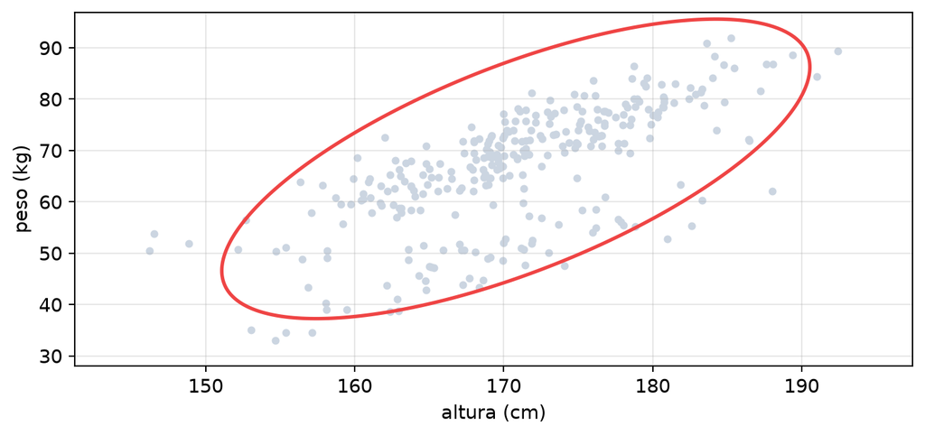

- $d^2(x)$ é a distância ao quadrado de cada ponto até o centro da nuvem, em unidades de desvio-padrão.
- Exemplo: a distância de qualquer ponto sobre a elipse até o centro é $6$.

## Limiar pelo qui-quadrado

- Se os dados seguem uma normal multivariada com $p$ colunas, então $d^2$ segue uma distribuição qui-quadrado com $p$ graus de liberdade.
- Isso permite definir um limiar sem precisar escolher um número arbitrário:

```python
from scipy.stats import chi2

for p in [2, 5, 20]:
    print(f"p = {p:>2} colunas: limiar (quantil 0.975) = {chi2.ppf(0.975, df=p):.1f}")
```

```
p =  2 colunas: limiar (quantil 0.975) = 7.4
p =  5 colunas: limiar (quantil 0.975) = 12.8
p = 20 colunas: limiar (quantil 0.975) = 34.2
```

## Mahalanobis em código

```python
from sklearn.covariance import EmpiricalCovariance

classic = EmpiricalCovariance().fit(measures)
d2_classic = classic.mahalanobis(measures)      # distância ao quadrado

threshold = chi2.ppf(0.975, df=2)
flagged = d2_classic > threshold

print(f"limiar: {threshold:.2f}")
print(f"identificados: {flagged.sum()} de {n}")
print(f"registros incorretos identificados: {flagged[broken].sum()} de {len(broken)}")
```

```
limiar: 7.38
identificados: 7 de 300
registros incorretos identificados: 4 de 60
```

## Mahalanobis também é mascarado

- $\mu$ e $\Sigma$ são estimados **incluindo os outliers**.
- Os $60$ registros quebrados esticam a elipse na direção deles.
- É o mesmo mascaramento do z-score, agora em duas dimensões. A solução também é a mesma: trocar a estimativa por uma versão robusta.

## Covariância robusta: MCD

- O **Minimum Covariance Determinant** procura o subconjunto de $h$ pontos cuja covariância tem o menor determinante, ou seja, a nuvem mais compacta que se consegue formar.
- Média e covariância são estimadas só com esse subconjunto, e os demais pontos passam a ser medidos contra ele.

```python
MinCovDet(support_fraction=None, random_state=0)
```

- `support_fraction` é a fração $h/n$ usada. O padrão leva a um ponto de ruptura próximo de $50\%$.

## MCD em código

```python
from sklearn.covariance import MinCovDet

robust = MinCovDet(random_state=0).fit(measures)
d2_robust = robust.mahalanobis(measures)
flagged_robust = d2_robust > threshold

print(f"clássico: {flagged.sum():3d} identificados "
      f"| incorretos encontrados: {flagged[broken].sum()}/{len(broken)}")
print(f" robusto: {flagged_robust.sum():3d} identificados "
      f"| incorretos encontrados: {flagged_robust[broken].sum()}/{len(broken)}")
```

```
clássico:   7 identificados | incorretos encontrados: 4/60
 robusto:  66 identificados | incorretos encontrados: 60/60
```

## MCD em código

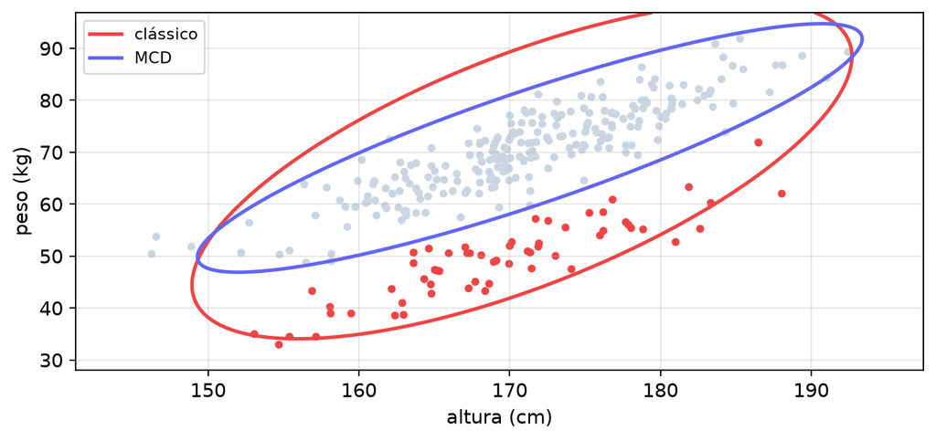

- O MCD define uma elipse considerando apenas os pontos do subconjunto mais compacto.

## `EllipticEnvelope`

- É o MCD embrulhado na interface de detector do sklearn.

```python
from sklearn.covariance import EllipticEnvelope

# contamination é a fração de outliers esperada
detector = EllipticEnvelope(contamination=0.2, random_state=0)
labels = detector.fit_predict(measures)    # +1 para normal, -1 para outlier

print(f"marcados: {(labels == -1).sum()}")
print(f"incorretos encontrados: {(labels[broken] == -1).sum()} de {len(broken)}")
```

```
marcados: 60
incorretos encontrados: 58 de 60
```

- `fit_predict` retorna rótulos. `score_samples` retorna a distância.

## Limites do Mahalanobis

- Supõe **uma única nuvem**, aproximadamente elipsoidal. Com dois grupos distintos, o centro cai no vazio entre eles.
- Captura apenas relação **linear** entre as colunas.
- Precisa estimar $\Sigma$, que tem $p(p+1)/2$ parâmetros. Com poucas linhas e muitas colunas a matriz fica malcondicionada ou singular.

## Exemplo de outliers não detectados pelo Mahalanobis

```python
rng_c = np.random.default_rng(5)

dense = rng_c.normal([0, 0], 0.3, (200, 2))        # grupo compacto
sparse = rng_c.normal([4, 4], 1.2, (200, 2))       # grupo espalhado

# 10 pontos ao redor do grupo compacto
noise = np.array([[1.2, 0.0], [0.0, 1.2], [-1.2, 0.3], [0.6, -1.1], [1.1, 1.1],
                  [1.9, 1.9], [-1.5, -1.0], [1.5, -0.8], [-0.8, 1.5], [2.1, 0.4]])
# 200 pontos em um grupo denso | 200 em um grupo esparso | 10 pontos de ruído
clusters = np.vstack([dense, sparse, noise])
```

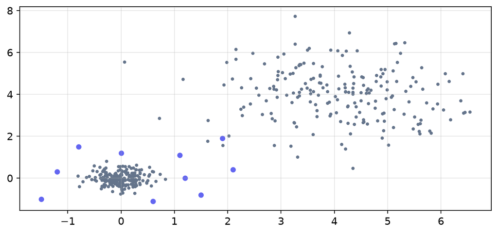

## Densidade local: LOF

- O `LocalOutlierFactor` compara a densidade ao redor de um ponto com a densidade ao redor dos seus $k$ vizinhos mais próximos.
- Razão próxima de $1$: o ponto é tão isolado quanto a vizinhança dele, então é normal.
- Razão bem acima de $1$: o ponto está em uma região muito mais vazia que a vizinhança.
- O que importa é a densidade **relativa**, não a distância absoluta.

## LOF em código

```python
from sklearn.neighbors import LocalOutlierFactor, NearestNeighbors

lof = LocalOutlierFactor(n_neighbors=20).fit(clusters)
# quanto maior, mais anômalo
lof_score = -lof.negative_outlier_factor_
# índices dos 10 pontos mais anômalos
ranking = np.argsort(lof_score)[::-1][:10]
print(f"{(ranking >= 400).sum()} dos 10 ruídos identificados")
```

```
9 dos 10 ruídos identificados
```

- A distância global elege as bordas do grupo espalhado. O LOF encontra o ruído.

## LOF e novidade

```python
LocalOutlierFactor(n_neighbors=20, novelty=True)
```

- Com `novelty=False`, que é o padrão, o LOF só pontua os próprios dados de treino. Usado para identificar valores anômalos em dados existentes.
- Com `novelty=True`, ele guarda a estrutura de vizinhança e passa a aceitar `predict` e `score_samples` em dados novos. Usado para encontrar novidades em dados que chegam depois do treino.

## `IsolationForest`

- Constrói árvores escolhendo, a cada nó, uma coluna ao acaso e um ponto de corte ao acaso, até isolar cada observação em uma folha.
- Um ponto em região vazia é separado com poucos cortes, então fica em uma folha rasa.
- O score é a profundidade média do ponto ao longo de muitas árvores.
- Não estima densidade nem distância. Ele mede quão fácil é separar o ponto do resto.

## `IsolationForest` em código

```python
from sklearn.ensemble import IsolationForest

forest = IsolationForest(n_estimators=200, contamination="auto", random_state=0)
forest.fit(clusters)
# quanto menor, mais anômalo
scores = forest.score_samples(clusters)
# os 10 pontos mais anômalos
ranking = np.argsort(scores)[:10]
print(f"{(ranking >= 400).sum()} dos 10 ruídos identificados.")
```

```
4 dos 10 ruídos identificados.
```

- O `IsolationForest` é um método **global**. Nesses dados com dois grupos de densidades bem diferentes, ele perde para o LOF.

## `IsolationForest` é muito usado em produção

- Custo praticamente linear no número de linhas.
- Poucos hiperparâmetros sensíveis. Na maior parte dos casos o padrão já funciona.
- Suporta grande quantidade de colunas melhor que os métodos baseados em distância.
- Como trabalha com cortes em uma coluna de cada vez, é indiferente a escala e a qualquer transformação monotônica.

## O parâmetro `contamination`

- `contamination` é a fração de outliers esperada.
- `contamination=0.1` identifica os 10% mais anômalos.
- `contamination="auto"` usa uma heurística para estimar a fração de outliers.
- Recomendação prática: manter `contamination="auto"`, trabalhar com `score_samples`, ordenar e inspecionar o topo da lista.

## Comparando os métodos

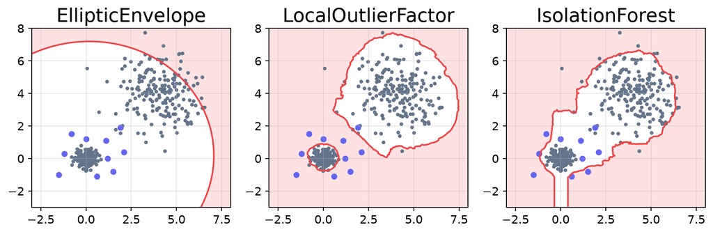

- A região avermelhada é a marcada como anômala.

## Dimensionalidade alta

- Com muitas colunas, as distâncias entre pares de pontos ficam todas parecidas. Métodos baseados em distância e em densidade degradam.
- Além disso, o ponto anômalo costuma estar fora do padrão em **poucas** colunas, e o sinal se dilui nas demais.
- Encaminhamentos usuais: reduzir a dimensão antes (assunto de próximas aulas), aplicar o detector em subconjuntos de colunas, ou usar o `IsolationForest`.

## Como avaliar outliers

- Sem rótulo real de anomalia, nenhum número diz se a detecção está boa.
- O que se faz na prática:
  - Ordenar pelo score e **inspecionar manualmente** os primeiros casos.
  - Verificar se métodos diferentes concordam sobre os mesmos registros.

## Quadro-resumo dos métodos

| Método | Robusto | Escala importa | Custo |  |
| --- | --- | --- | --- | --- |
| z-score | não | sim | baixo |  |
| z robusto (MAD) | sim | sim | baixo |  |
| IQR e percentil | sim | sim | baixo |  |
| Mahalanobis | não | não | médio |  |
| `EllipticEnvelope` (MCD) | sim | não | médio |  |
| `LocalOutlierFactor` | parcial | sim | alto |  |
| `IsolationForest` | sim | não | baixo |  |

# O que fazer com os outliers

## Seis ações possíveis

1. **Corrigir** o valor, quando o valor certo é recuperável.
2. **Descartar** a linha.
3. **Limitar** o valor a um teto e a um piso (*winsorização*).
4. **Sinalizar** com uma coluna nova e manter o valor original.
5. **Tratar como ausente** e utilizar as ideias de imputação.
6. **Não mexer nos dados** e usar estatísticas e modelos robustos.

## Limitar (winsorização)

- Winsorização é a substituição de valores extremos por um limite superior ou inferior:

```python
def limits_iqr(x, factor=1.5):
    """Limites pela regra do intervalo interquartil."""
    q1, q3 = np.percentile(x, [25, 75])
    return q1 - factor*(q3 - q1), q3 + factor*(q3 - q1)

# aprendizado de limites robustos
lower, upper = limits_iqr(train)
# aplicação no conjunto de teste
test_capped = np.clip(test, lower, upper)
```

- Todo valor acima de upper é substituído por upper. E todo valor abaixo de lower é substituído por lower.

## Usar métodos robustos

- Muitas vezes a melhor resposta é não alterar os dados e trocar o método.
- Resumo: mediana no lugar da média, quantis no lugar do desvio-padrão.
- Ajuste: erro absoluto ou perda de Huber no lugar do erro quadrático.
- Modelos: árvores e *gradient boosting* que dependem só da ordem dos valores.
- Pré-processamento: `RobustScaler`, `log1p` e discretização por quantis, vistos em outras aulas.

## Quadro de decisão

| Situação | Ação usual |
| --- | --- |
| Valor impossível pela regra de domínio | corrigir ou tratar como ausente |
| Sentinela numérica conhecida | converter para ausente antes de qualquer estatística |
| Cauda longa legítima | transformar a escala, limitar, ou usar modelo robusto |
| Poucos registros claramente errados | descartar |
| Regime novo ou suspeita de fraude | sinalizar, investigar e registrar |
| Origem desconhecida | sinalizar e manter o valor original |

## Cuidado! Vazamento de dados

- Todo limiar de corte é um **parâmetro aprendido**: média, mediana, MAD, quantis, covariância.
- Calcular os limites sobre a base inteira deixa o teste influenciar o pré-processamento.
- Remover linhas do conjunto de teste pode ser mais grave: Apaga justamente os casos difíceis e infla a métrica sem que o modelo tenha melhorado.

# Outliers em produção

## O detector como sensor

- Em tratamento de dados, o uso mais valioso de um detector não é limpar linhas. É avisar que **algo mudou na origem**.
- A taxa de registros marcados por lote é uma métrica barata de monitorar e costuma reagir antes de qualquer métrica de modelo.

## O detector como sensor

- Vamos simular leituras de um sensor de temperatura, com 200 leituras por dia durante 60 dias.
- No dia 40 o sensor desconfigurou/resetou e passou a reportar em Fahrenheit:

```python
rng_b = np.random.default_rng(6)

batches = []
for day in range(60):
    # 200 leituras por dia de um sensor em graus Celsius
    values = rng_b.normal(20, 2, 200)
    if day >= 40:
        # O sensor passou a reportar em Fahrenheit
        values[:40] = values[:40]*9/5 + 32
    batches.append(values)
```

## Monitorar a taxa de marcação

```python
def limits_mad(x, factor=3.5):
    """Limites pelo z robusto baseado no MAD."""
    median = np.median(x)
    delta = factor*np.median(np.abs(x - median)) / 0.6745
    return median - delta, median + delta

# as três primeiras semanas como referência
baseline = np.concatenate(batches[:20])
lower, upper = limits_mad(baseline)

rates = []
for daily_values in batches:
    outside = (daily_values < lower) | (daily_values > upper)
    rate = outside.mean()
    rates.append(rate)

print(f"taxa nos dias 35 a 39:  {np.array(rates[35:40])}")
print(f"taxa nos dias 40 a 45: {np.array(rates[40:46])}")
```

```
taxa nos dias 35 a 39:  [0. 0. 0. 0. 0.]
taxa nos dias 40 a 45: [0.2   0.2   0.2   0.205 0.2   0.2  ]
```

## Monitorar a taxa de marcação

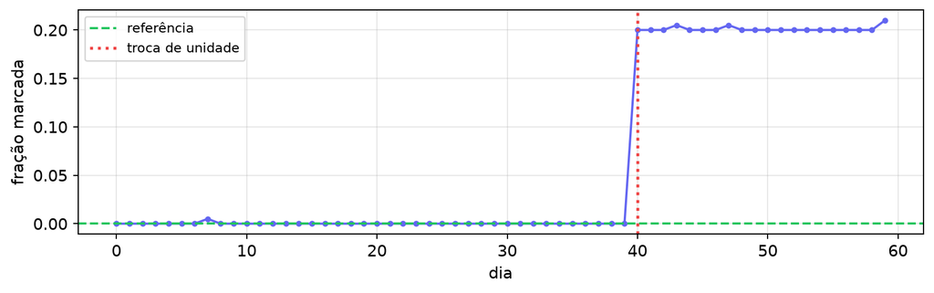

- A alteração é identificada imediatamente.

## Assuntos adicionais

- Outliers em séries temporais exigem uma referência **local**. As abordagens usuais são a mediana móvel com MAD móvel, ou o resíduo de uma decomposição em tendência e sazonalidade.
- **Quando existem rótulos:** detecção de fraude e de falha deixa de ser um problema não supervisionado e vira classificação com desbalanceamento severo.
- A biblioteca `PyOD` reúne dezenas de algoritmos de detecção de outliers com a mesma interface do sklearn.